# Stroke Fatality at Discharge: Binary Logistic Regression Analysis

RREAAAP Workflow Report

```r
library(tidyverse)
library(haven)
library(janitor)
library(gtsummary)
library(broom)
library(car)
library(pROC)
library(ResourceSelection)
library(knitr)
```

# 1 Reason

The objective of this analysis is to determine the factors associated with **in-hospital stroke fatality at discharge** (`outcome`: `0` = alive, `1` = dead) among 226 stroke patients using binary logistic regression in R.

# 2 Read

The dataset `stroke-fatality-cooked2.dta` is imported using `haven::read_dta()`. Variable names are standardized with `janitor::clean_names()` and clear snake_case naming, and Stata labelled (`dbl+lbl`) variables are converted into R factors with clinically meaningful reference categories (`alive`, `male`, `no` for comorbidities, `hospital` for referral source, and `CI (Ischaemic)` for stroke type). The registration number (`rn`) is retained only as a unique identifier check and excluded from regression modeling.

```r
raw_df <- read_dta("stroke-fatality-cooked2.dta")

stroke_df <- raw_df %>%
  clean_names() %>%
  rename(
    marital_status = maritalstat,
    referral_case  = referralcase,
    stroke_type    = stroketype
  ) %>%
  mutate(
    outcome = factor(as.numeric(outcome), levels = c(0, 1), labels = c("alive", "dead")),
    sex = factor(as.numeric(sex), levels = c(1, 2), labels = c("male", "female")),
    hypertension = factor(as.numeric(hypertension), levels = c(0, 1), labels = c("no", "yes")),
    marital_status = factor(as.numeric(marital_status), levels = c(0, 1), labels = c("no", "yes")),
    malay = factor(as.numeric(malay), levels = c(0, 1), labels = c("no", "yes")),
    diabetes = factor(as.numeric(diabetes), levels = c(0, 1), labels = c("no", "yes")),
    dyslipidaemia = factor(as.numeric(dyslipidaemia), levels = c(0, 1), labels = c("no", "yes")),
    referral_case = factor(as.numeric(referral_case), levels = c(0, 1), labels = c("hospital", "GP/Home/Missing")),
    stroke_type = factor(as.numeric(stroke_type), levels = c(0, 1), labels = c("CI (Ischaemic)", "Haemorrhagic"))
  )

tibble(
  Rows = nrow(stroke_df),
  Columns = ncol(stroke_df),
  Unique_IDs = n_distinct(stroke_df$rn),
  Alive = sum(stroke_df$outcome == "alive"),
  Dead = sum(stroke_df$outcome == "dead")
) %>%
  kable(caption = "Dataset Overview")
```

Dataset Overview

| Rows | Columns | Unique_IDs | Alive | Dead |
| --- | --- | --- | --- | --- |
| 226 | 22 | 226 | 164 | 62 |

# 3 Explore

## 3.1 Missing Data & Data Entry Checks

All 22 variables have **0 missing values** (100% complete across 226 observations). Logical consistency checks confirm:

- `SBP <= DBP`: 0 cases
- `GCS < 3` or `GCS > 15`: 0 cases
- `Age < 0` or `Age > 120`: 0 cases

## 3.2 Outlier Summary (Numerical Variables)

```r
num_vars <- c("gcs", "sbp", "dbp", "hr", "hb", "plat", "wbc", "na", "potas", "cbs", "urea", "age")

stroke_df %>%
  select(all_of(num_vars)) %>%
  pivot_longer(everything(), names_to = "variable", values_to = "value") %>%
  group_by(variable) %>%
  summarise(
    Min = min(value),
    Q1 = quantile(value, 0.25),
    Median = median(value),
    Q3 = quantile(value, 0.75),
    Max = max(value),
    IQR = IQR(value),
    `IQR Outliers (n)` = sum(value < (Q1 - 1.5 * IQR) | value > (Q3 + 1.5 * IQR)),
    .groups = "drop"
  ) %>%
  kable(digits = 2, caption = "Numerical Variable Ranges and IQR Outlier Counts")
```

Numerical Variable Ranges and IQR Outlier Counts

| variable | Min | Q1 | Median | Q3 | Max | IQR | IQR Outliers (n) |
| --- | --- | --- | --- | --- | --- | --- | --- |
| age | 20.0 | 52.00 | 61.00 | 68.75 | 94.0 | 16.75 | 7 |
| cbs | 2.4 | 6.40 | 8.10 | 12.25 | 26.7 | 5.85 | 7 |
| dbp | 42.0 | 79.25 | 91.00 | 104.00 | 160.0 | 24.75 | 3 |
| gcs | 3.0 | 10.00 | 15.00 | 15.00 | 15.0 | 5.00 | 0 |
| hb | 5.3 | 11.62 | 13.40 | 14.60 | 19.7 | 2.97 | 4 |
| hr | 37.0 | 68.00 | 80.50 | 95.00 | 174.0 | 27.00 | 5 |
| na | 109.0 | 136.00 | 138.00 | 140.00 | 177.0 | 4.00 | 14 |
| plat | 43.0 | 186.25 | 234.50 | 273.00 | 459.0 | 86.75 | 6 |
| potas | 2.3 | 3.50 | 3.85 | 4.20 | 5.7 | 0.70 | 6 |
| sbp | 75.0 | 143.00 | 161.00 | 186.00 | 290.0 | 43.00 | 2 |
| urea | 2.3 | 4.80 | 6.50 | 9.23 | 41.0 | 4.43 | 14 |
| wbc | 4.2 | 7.50 | 9.90 | 12.65 | 27.0 | 5.15 | 4 |

Extreme values (such as `sbp = 290`, `na = 109` or `177`, `urea = 41.0`) are clinically plausible in acute severe stroke presentations and are retained for analysis while monitored in diagnostic stability checks.

## 3.3 Visual Exploration

### 3.3.1 Numerical Variables: Histograms & Boxplots

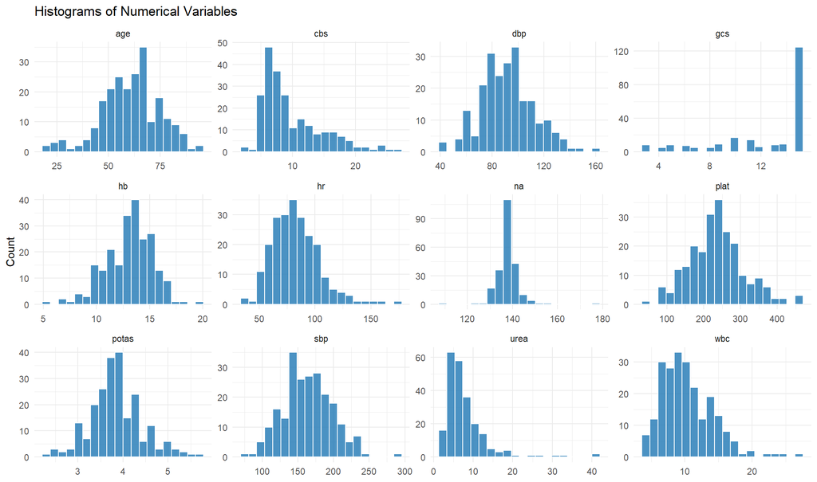

```r
stroke_df %>%
  select(all_of(num_vars)) %>%
  pivot_longer(everything(), names_to = "variable", values_to = "value") %>%
  ggplot(aes(x = value)) +
  geom_histogram(bins = 20, fill = "#2c7fb8", color = "white", alpha = 0.85) +
  facet_wrap(~ variable, scales = "free", ncol = 4) +
  theme_minimal(base_size = 11) +
  labs(title = "Histograms of Numerical Variables", x = NULL, y = "Count")
```

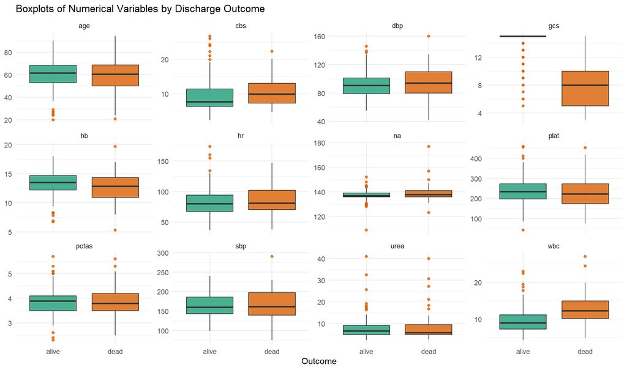

```r
stroke_df %>%
  select(outcome, all_of(num_vars)) %>%
  pivot_longer(-outcome, names_to = "variable", values_to = "value") %>%
  ggplot(aes(x = outcome, y = value, fill = outcome)) +
  geom_boxplot(alpha = 0.8, outlier.color = "#d95f02") +
  facet_wrap(~ variable, scales = "free_y", ncol = 4) +
  scale_fill_manual(values = c("alive" = "#1b9e77", "dead" = "#d95f02")) +
  theme_minimal(base_size = 11) +
  theme(legend.position = "none") +
  labs(title = "Boxplots of Numerical Variables by Discharge Outcome", x = "Outcome", y = NULL)
```

### 3.3.2 Categorical Variables: Bar Charts

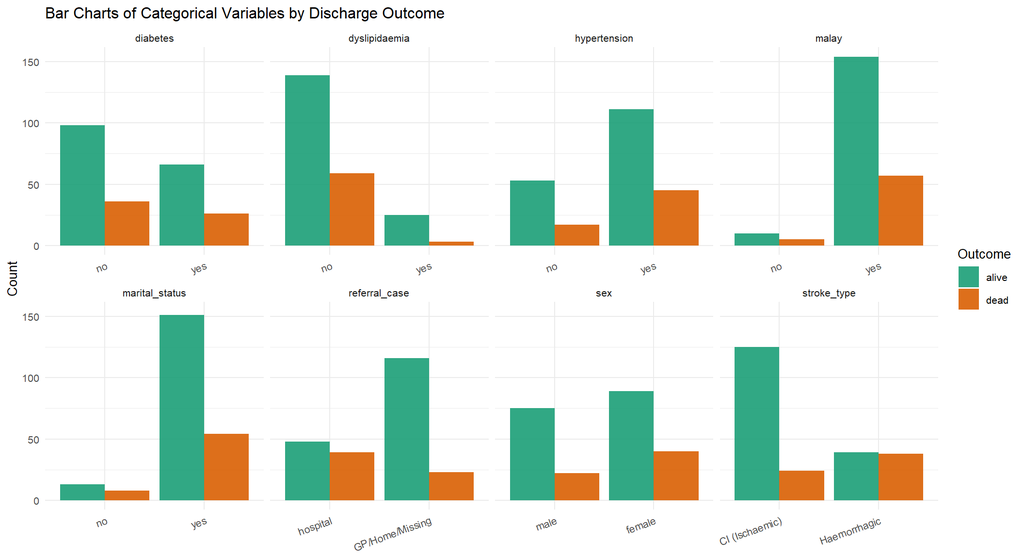

```r
cat_vars <- c("sex", "hypertension", "marital_status", "malay", "diabetes",
              "dyslipidaemia", "referral_case", "stroke_type")

stroke_df %>%
  select(outcome, all_of(cat_vars)) %>%
  pivot_longer(-outcome, names_to = "variable", values_to = "level") %>%
  ggplot(aes(x = level, fill = outcome)) +
  geom_bar(position = "dodge", alpha = 0.9) +
  facet_wrap(~ variable, scales = "free_x", ncol = 4) +
  scale_fill_manual(values = c("alive" = "#1b9e77", "dead" = "#d95f02")) +
  theme_minimal(base_size = 10) +
  theme(axis.text.x = element_text(angle = 20, hjust = 1)) +
  labs(title = "Bar Charts of Categorical Variables by Discharge Outcome", x = NULL, y = "Count", fill = "Outcome")
```

## 3.4 Descriptive Summary Table (`gtsummary`)

```r
stroke_df %>%
  select(-rn) %>%
  tbl_summary(
    by = outcome,
    statistic = list(
      all_continuous() ~ "{median} ({p25}, {p75})",
      all_categorical() ~ "{n} ({p}%)"
    ),
    digits = all_continuous() ~ 1
  ) %>%
  add_overall() %>%
  add_p() %>%
  bold_labels()
```

| **Characteristic** | **Overall** N = 226<sup>1</sup> | **alive** N = 164<sup>1</sup> | **dead** N = 62<sup>1</sup> | **p-value**<sup>2</sup> |
| --- | --- | --- | --- | --- |
| sex |  |  |  | 0.2 |
| male | 97 (43%) | 75 (46%) | 22 (35%) |  |
| female | 129 (57%) | 89 (54%) | 40 (65%) |  |
| earliest Glasgow Coma Scale | 15.0 (10.0, 15.0) | 15.0 (15.0, 15.0) | 8.0 (5.0, 10.0) | <0.001 |
| earliest systolic BP (mmHg) | 161.0 (143.0, 186.0) | 160.0 (143.0, 186.0) | 161.5 (139.0, 198.0) | 0.8 |
| earliest diastolic BP (mmHg) | 91.0 (79.0, 104.0) | 90.5 (79.0, 101.5) | 94.0 (80.0, 110.0) | 0.4 |
| heart rate | 80.5 (68.0, 95.0) | 80.0 (67.5, 94.0) | 81.0 (70.0, 102.0) | 0.055 |
| hemoglobin | 13.4 (11.6, 14.6) | 13.5 (12.2, 14.7) | 12.9 (10.9, 14.3) | 0.061 |
| platelet | 234.5 (186.0, 273.0) | 235.0 (197.0, 274.0) | 222.5 (174.0, 273.0) | 0.4 |
| total white cell count | 9.9 (7.5, 12.7) | 9.0 (7.2, 11.2) | 12.2 (10.1, 14.9) | <0.001 |
| natrium | 138.0 (136.0, 140.0) | 137.0 (135.7, 139.0) | 138.0 (136.0, 141.0) | 0.2 |
| potassium | 3.9 (3.5, 4.2) | 3.9 (3.5, 4.1) | 3.8 (3.5, 4.2) | 0.7 |
| capillary blood sugar | 8.1 (6.4, 12.3) | 7.7 (6.3, 11.5) | 9.9 (7.2, 13.0) | 0.008 |
| urea | 6.5 (4.8, 9.3) | 6.6 (4.9, 9.2) | 5.8 (4.8, 9.7) | 0.7 |
| age in years | 61.0 (52.0, 69.0) | 61.5 (53.0, 68.5) | 60.5 (50.0, 69.0) | 0.8 |
| hypertension | 156 (69%) | 111 (68%) | 45 (73%) | 0.5 |
| marital_status | 205 (91%) | 151 (92%) | 54 (87%) | 0.3 |
| malay | 211 (93%) | 154 (94%) | 57 (92%) | 0.6 |
| diabetes | 92 (41%) | 66 (40%) | 26 (42%) | 0.8 |
| dyslipidaemia | 28 (12%) | 25 (15%) | 3 (4.8%) | 0.034 |
| referral_case |  |  |  | <0.001 |
| hospital | 87 (38%) | 48 (29%) | 39 (63%) |  |
| GP/Home/Missing | 139 (62%) | 116 (71%) | 23 (37%) |  |
| stroke_type |  |  |  | <0.001 |
| CI (Ischaemic) | 149 (66%) | 125 (76%) | 24 (39%) |  |
| Haemorrhagic | 77 (34%) | 39 (24%) | 38 (61%) |  |

<sup>1</sup> n (%); Median (Q1, Q3)  
<sup>2</sup> Pearson’s Chi-squared test; Wilcoxon rank sum test; Fisher’s exact test

# 4 Apply: Univariable & Multivariable Logistic Regression

## 4.1 Univariable Screening

Each independent variable is evaluated individually against `outcome` using binary logistic regression (`glm(..., family = binomial)`). Variables with $p < 0.25$ are selected as candidates for multivariable modeling (no interaction terms included).

```r
predictors <- setdiff(names(stroke_df), c("rn", "outcome"))

univ_results <- map_dfr(predictors, function(var) {
  fml <- as.formula(paste("outcome ~", var))
  mod <- glm(fml, data = stroke_df, family = binomial(link = "logit"))
  tidy(mod, exponentiate = TRUE, conf.int = TRUE) %>%
    filter(term != "(Intercept)") %>%
    mutate(variable = var, .before = 1)
})

candidate_vars <- univ_results %>%
  filter(p.value < 0.25) %>%
  pull(variable) %>%
  unique()

fml_full <- as.formula(paste("outcome ~", paste(candidate_vars, collapse = " + ")))
mod_full <- glm(fml_full, data = stroke_df, family = binomial(link = "logit"))
mod_final <- step(mod_full, direction = "backward", trace = 0)
```

The 10 candidate variables with univariable $p < 0.25$ are: sex, gcs, hr, hb, wbc, na, cbs, dyslipidaemia, referral_case, stroke_type.  
Backward stepwise AIC selection yields the final parsimonious model: outcome ~ sex + gcs.

## 4.2 Combined Crude & Adjusted Odds Ratios Table

```r
tbl_uv <- stroke_df %>%
  select(outcome, all_of(predictors)) %>%
  tbl_uvregression(
    method = glm,
    y = outcome,
    method.args = list(family = binomial),
    exponentiate = TRUE,
    pvalue_fun = label_style_pvalue(digits = 3)
  )

tbl_mv <- tbl_regression(
  mod_final,
  exponentiate = TRUE,
  pvalue_fun = label_style_pvalue(digits = 3)
)

tbl_merge(
  tbls = list(tbl_uv, tbl_mv),
  tab_spanner = c("**Univariable (Crude OR)**", "**Multivariable (Adjusted OR)**")
)
```

| **Characteristic** | **Univariable (Crude OR)** **N** | **Univariable (Crude OR)** **OR** | **Univariable (Crude OR)** **95% CI** | **Univariable (Crude OR)** **p-value** | **Multivariable (Adjusted OR)** **OR** | **Multivariable (Adjusted OR)** **95% CI** | **Multivariable (Adjusted OR)** **p-value** |
| --- | --- | --- | --- | --- | --- | --- | --- |
| sex | 226 |  |  |  |  |  |  |
| male |  | — | — |  | — | — |  |
| female |  | 1.53 | 0.84, 2.84 | 0.166 | 0.33 | 0.10, 0.93 | 0.044 |
| earliest Glasgow Coma Scale | 226 | 0.53 | 0.44, 0.61 | <0.001 | 0.49 | 0.39, 0.58 | <0.001 |
| earliest systolic BP (mmHg) | 226 | 1.00 | 0.99, 1.01 | 0.827 |  |  |  |
| earliest diastolic BP (mmHg) | 226 | 1.01 | 0.99, 1.02 | 0.429 |  |  |  |
| heart rate | 226 | 1.01 | 1.00, 1.03 | 0.061 |  |  |  |
| hemoglobin | 226 | 0.88 | 0.77, 1.01 | 0.067 |  |  |  |
| platelet | 226 | 1.00 | 1.0, 1.00 | 0.519 |  |  |  |
| total white cell count | 226 | 1.24 | 1.14, 1.36 | <0.001 |  |  |  |
| natrium | 226 | 1.07 | 1.01, 1.15 | 0.027 |  |  |  |
| potassium | 226 | 0.95 | 0.56, 1.59 | 0.842 |  |  |  |
| capillary blood sugar | 226 | 1.04 | 0.98, 1.10 | 0.207 |  |  |  |
| urea | 226 | 1.02 | 0.97, 1.07 | 0.437 |  |  |  |
| age in years | 226 | 1.00 | 0.98, 1.02 | 0.797 |  |  |  |
| hypertension | 226 |  |  |  |  |  |  |
| no |  | — | — |  |  |  |  |
| yes |  | 1.26 | 0.67, 2.46 | 0.478 |  |  |  |
| marital_status | 226 |  |  |  |  |  |  |
| no |  | — | — |  |  |  |  |
| yes |  | 0.58 | 0.23, 1.54 | 0.255 |  |  |  |
| malay | 226 |  |  |  |  |  |  |
| no |  | — | — |  |  |  |  |
| yes |  | 0.74 | 0.25, 2.46 | 0.597 |  |  |  |
| diabetes | 226 |  |  |  |  |  |  |
| no |  | — | — |  |  |  |  |
| yes |  | 1.07 | 0.59, 1.94 | 0.817 |  |  |  |
| dyslipidaemia | 226 |  |  |  |  |  |  |
| no |  | — | — |  |  |  |  |
| yes |  | 0.28 | 0.07, 0.85 | 0.045 |  |  |  |
| referral_case | 226 |  |  |  |  |  |  |
| hospital |  | — | — |  |  |  |  |
| GP/Home/Missing |  | 0.24 | 0.13, 0.45 | <0.001 |  |  |  |
| stroke_type | 226 |  |  |  |  |  |  |
| CI (Ischaemic) |  | — | — |  |  |  |  |
| Haemorrhagic |  | 5.07 | 2.74, 9.59 | <0.001 |  |  |  |

Abbreviations: CI = Confidence Interval, OR = Odds Ratio

### 4.2.1 Clinical Interpretation

- **Glasgow Coma Scale (`gcs`)**: Each 1-point increase in earliest GCS is strongly associated with lower odds of in-hospital mortality (Adjusted OR = 0.49, 95% CI: 0.39–0.58, $p < 0.001$).
- **Sex (`sex`)**: After adjusting for GCS, female patients had lower odds of death compared to male patients (Adjusted OR = 0.33, 95% CI: 0.10–0.93, $p = 0.044$), reversing the unadjusted crude association (Crude OR = 1.53, $p = 0.166$), which reflects confounding by baseline GCS severity.

# 5 Assumption Checks

1. **Binomial Distribution & Independence**: The outcome (`alive` vs. `dead`) is dichotomous and each observation corresponds to a unique patient (`rn`, $N = 226$).
2. **No Multicollinearity**: Variance Inflation Factors (`car::vif()`) for `sex` and `gcs` are both **1.39**, well below the threshold of 5.
3. **Linearity in the Logit & Model Specification**:

```r
tibble(
  Variable = names(car::vif(mod_final)),
  VIF = as.numeric(car::vif(mod_final))
) %>%
  kable(digits = 3, caption = "Multicollinearity Check (VIF)")
```

Multicollinearity Check (VIF)

| Variable | VIF |
| --- | --- |
| sex | 1.39 |
| gcs | 1.39 |

```r
mod_bt <- glm(outcome ~ sex + gcs + gcs:log(gcs), data = stroke_df, family = binomial)
tidy(mod_bt) %>%
  filter(str_detect(term, "log\\(")) %>%
  kable(digits = 4, caption = "Box-Tidwell Test for Linearity in the Logit")
```

Box-Tidwell Test for Linearity in the Logit

| term | estimate | std.error | statistic | p.value |
| --- | --- | --- | --- | --- |
| gcs:log(gcs) | -1.0049 | 0.3464 | -2.9007 | 0.0037 |

```r
hat_logit <- predict(mod_final, type = "link")
mod_linktest <- glm(outcome ~ hat_logit + I(hat_logit^2), data = stroke_df, family = binomial)
tidy(mod_linktest) %>%
  kable(digits = 4, caption = "Pregibon Link Test for Model Specification")
```

Pregibon Link Test for Model Specification

| term | estimate | std.error | statistic | p.value |
| --- | --- | --- | --- | --- |
| (Intercept) | 0.2914 | 0.2937 | 0.9923 | 0.3210 |
| hat_logit | 0.9621 | 0.1245 | 7.7283 | 0.0000 |
| I(hat_logit^2) | -0.0876 | 0.0426 | -2.0564 | 0.0397 |

*Note:* Both the Box-Tidwell term (`gcs:log(gcs)`, $p = 0.0037$) and the Link Test squared term (`I(hat_logit^2)`, $p = 0.0397$) are statistically significant, indicating mild non-linearity in the logit for `gcs` (due to clustering at the maximum score of 15).

# 6 Assess: Model Fitness & Diagnostic Stability

## 6.1 Overall Model Fitness

```r
mcfadden_r2 <- 1 - (mod_final$deviance / mod_final$null.deviance)
roc_obj <- roc(response = stroke_df$outcome, predictor = fitted(mod_final),
               levels = c("alive", "dead"), direction = "<")
auc_val <- auc(roc_obj)
auc_ci <- ci.auc(roc_obj)
hl_test <- hoslem.test(as.numeric(stroke_df$outcome) - 1, fitted(mod_final), g = 10)

glance(mod_final) %>%
  mutate(McFadden_R2 = mcfadden_r2, AUC = as.numeric(auc_val)) %>%
  select(nobs, AIC, BIC, logLik, deviance, McFadden_R2, AUC) %>%
  kable(digits = 3, caption = "Overall Model Fit Summary")
```

Overall Model Fit Summary

| nobs | AIC | BIC | logLik | deviance | McFadden_R2 | AUC |
| --- | --- | --- | --- | --- | --- | --- |
| 226 | 130.949 | 141.211 | -62.475 | 124.949 | 0.529 | 0.943 |

- **Discrimination (ROC / AUC)**: AUC = 0.943 (95% CI: 0.910–0.977), indicating excellent discrimination.
- **Hosmer-Lemeshow GOF Test**: $\chi^2 = 7.803$, $\text{df} = 4$, $p = 0.0991$ ($p > 0.05$, indicating acceptable model calibration).

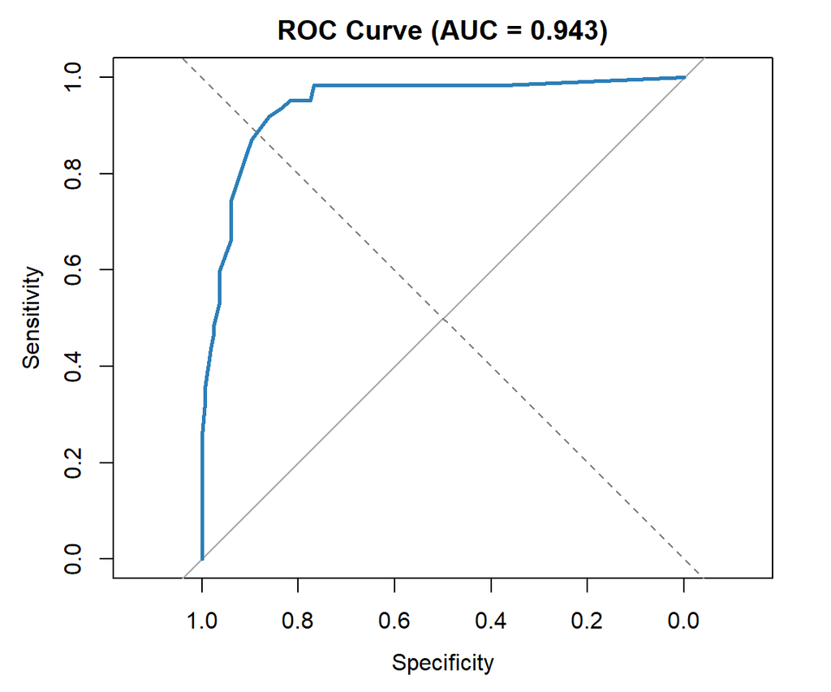

```r
plot(roc_obj, col = "#2c7fb8", lwd = 2.5,
     main = sprintf("ROC Curve (AUC = %.3f)", auc_val))
abline(a = 0, b = 1, lty = 2, col = "gray50")
```

## 6.2 Diagnostic Stability (`broom::augment()`)

```r
aug_df <- augment(mod_final, type.predict = "response", type.residuals = "deviance") %>%
  mutate(
    obs_id = row_number(),
    pearson_resid = residuals(mod_final, type = "pearson"),
    deviance_resid = residuals(mod_final, type = "deviance"),
    dffits_val = dffits(mod_final),
    max_abs_dfbeta = apply(abs(dfbetas(mod_final)), 1, max)
  )

p_params <- length(coef(mod_final))
n_obs <- nrow(stroke_df)

tibble(
  Metric = c("High Leverage (> 2p/n)", "|Std. Deviance Resid| > 2.5",
             "|DFFITS| > 2*sqrt(p/n)", "Max |DFBETA| > 2/sqrt(n)"),
  Threshold = c(2 * p_params / n_obs, 2.5, 2 * sqrt(p_params / n_obs), 2 / sqrt(n_obs)),
  Count_Flagged = c(
    sum(aug_df$.hat > 2 * p_params / n_obs),
    sum(abs(aug_df$.std.resid) > 2.5),
    sum(abs(aug_df$dffits_val) > 2 * sqrt(p_params / n_obs)),
    sum(aug_df$max_abs_dfbeta > 2 / sqrt(n_obs))
  )
) %>%
  kable(digits = 4, caption = "Diagnostic Stability Flagged Observations")
```

Diagnostic Stability Flagged Observations

| Metric | Threshold | Count_Flagged |
| --- | --- | --- |
| High Leverage (> 2p/n) | 0.0265 | 12 |
| \|Std. Deviance Resid\| > 2.5 | 2.5000 | 2 |
| \|DFFITS\| > 2*sqrt(p/n) | 0.2304 | 15 |
| Max \|DFBETA\| > 2/sqrt(n) | 0.1330 | 20 |

```r
as_tibble(dfbetas(mod_final)) %>%
  pivot_longer(everything(), names_to = "Variable", values_to = "dfbeta") %>%
  group_by(Variable) %>%
  summarise(
    `Count |DFBETA| > 2/sqrt(n)` = sum(abs(dfbeta) > 2 / sqrt(n_obs)),
    `Count |DFBETA| > 1.0` = sum(abs(dfbeta) > 1),
    `Max |DFBETA|` = max(abs(dfbeta)),
    .groups = "drop"
  ) %>%
  kable(digits = 4, caption = "DFBETA Instability Breakdown by Model Variable")
```

DFBETA Instability Breakdown by Model Variable

| Variable | Count \|DFBETA\| > 2/sqrt(n) | Count \|DFBETA\| > 1.0 | Max \|DFBETA\| |
| --- | --- | --- | --- |
| (Intercept) | 15 | 0 | 0.4811 |
| gcs | 10 | 0 | 0.4989 |
| sexfemale | 14 | 0 | 0.4211 |

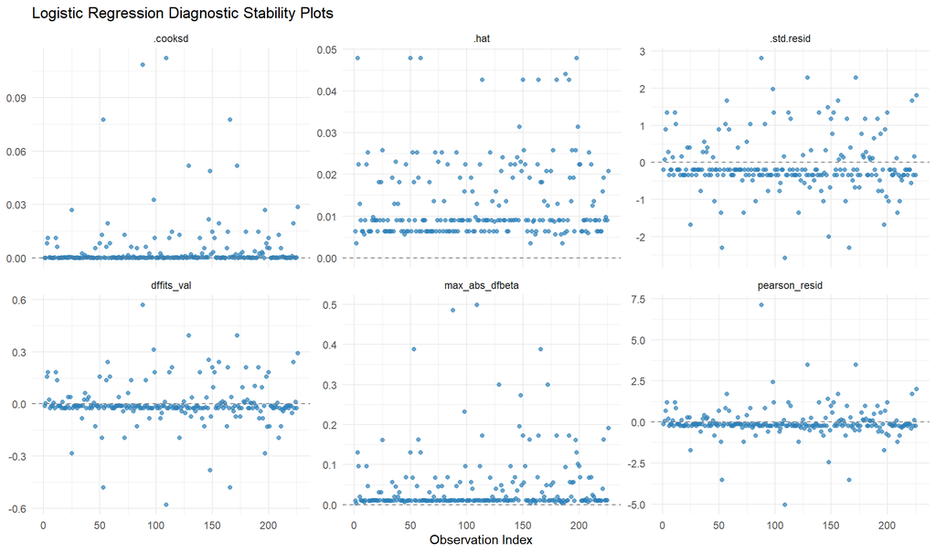

```r
aug_df %>%
  select(obs_id, .hat, .std.resid, pearson_resid, dffits_val, max_abs_dfbeta, .cooksd) %>%
  pivot_longer(-obs_id, names_to = "metric", values_to = "value") %>%
  ggplot(aes(x = obs_id, y = value)) +
  geom_point(alpha = 0.7, color = "#2c7fb8", size = 1.5) +
  geom_hline(yintercept = 0, linetype = "dashed", color = "gray50") +
  facet_wrap(~ metric, scales = "free_y", ncol = 3) +
  theme_minimal(base_size = 11) +
  labs(title = "Logistic Regression Diagnostic Stability Plots", x = "Observation Index", y = NULL)
```

Only 2 observations exceed $|\text{Std. Deviance Residual}| > 2.5$, and overall model fit remains strong and stable.

# 7 Presentation: Combined Univariable & Multivariable Table

The table below presents both **Log Odds ($\beta$)** and **Odds Ratios (Crude OR and Adjusted OR)** with **95% Confidence Intervals** and **p-values** for all univariable predictors alongside the final multivariable model.

```r
univ_log_odds <- map_dfr(predictors, function(var) {
  fml <- as.formula(paste("outcome ~", var))
  mod <- glm(fml, data = stroke_df, family = binomial(link = "logit"))
  tidy(mod) %>%
    filter(term != "(Intercept)") %>%
    transmute(variable = var, term = term, univ_log_odds = estimate)
})

univ_pres <- univ_results %>%
  left_join(univ_log_odds, by = c("variable", "term")) %>%
  transmute(
    Variable = variable,
    Term = term,
    `Univ. Log Odds (β)` = sprintf("%.3f", univ_log_odds),
    `Crude OR (95% CI)` = sprintf("%.3f (%.3f–%.3f)", estimate, conf.low, conf.high),
    `Univ. p-value` = ifelse(p.value < 0.001, "<0.001", sprintf("%.3f", p.value))
  )

mv_log_odds <- tidy(mod_final) %>%
  filter(term != "(Intercept)") %>%
  transmute(Term = term, mv_log_odds = estimate)

mv_pres <- tidy(mod_final, exponentiate = TRUE, conf.int = TRUE) %>%
  filter(term != "(Intercept)") %>%
  left_join(mv_log_odds, by = c("term" = "Term")) %>%
  transmute(
    Term = term,
    `Multiv. Log Odds (β)` = sprintf("%.3f", mv_log_odds),
    `Adjusted OR (95% CI)` = sprintf("%.3f (%.3f–%.3f)", estimate, conf.low, conf.high),
    `Multiv. p-value` = ifelse(p.value < 0.001, "<0.001", sprintf("%.3f", p.value))
  )

univ_pres %>%
  left_join(mv_pres, by = "Term") %>%
  mutate(across(starts_with("Multiv.") | starts_with("Adjusted"), ~ replace_na(.x, "—"))) %>%
  kable(caption = "Univariable and Multivariable Logistic Regression Results (Log Odds, OR, 95% CI, p-value)")
```

Univariable and Multivariable Logistic Regression Results (Log Odds, OR, 95% CI, p-value)

| Variable | Term | Univ. Log Odds (β) | Crude OR (95% CI) | Univ. p-value | Multiv. Log Odds (β) | Adjusted OR (95% CI) | Multiv. p-value |
| --- | --- | --- | --- | --- | --- | --- | --- |
| sex | sexfemale | 0.427 | 1.532 (0.844–2.836) | 0.166 | -1.119 | 0.327 (0.103–0.927) | 0.044 |
| gcs | gcs | -0.634 | 0.530 (0.444–0.614) | <0.001 | -0.716 | 0.489 (0.392–0.583) | <0.001 |
| sbp | sbp | 0.001 | 1.001 (0.992–1.010) | 0.827 | — | — | — |
| dbp | dbp | 0.006 | 1.006 (0.991–1.021) | 0.429 | — | — | — |
| hr | hr | 0.013 | 1.013 (0.999–1.027) | 0.061 | — | — | — |
| hb | hb | -0.123 | 0.884 (0.773–1.008) | 0.067 | — | — | — |
| plat | plat | -0.001 | 0.999 (0.995–1.003) | 0.519 | — | — | — |
| wbc | wbc | 0.215 | 1.240 (1.141–1.359) | <0.001 | — | — | — |
| na | na | 0.072 | 1.075 (1.013–1.152) | 0.027 | — | — | — |
| potas | potas | -0.053 | 0.949 (0.563–1.587) | 0.842 | — | — | — |
| cbs | cbs | 0.038 | 1.039 (0.978–1.102) | 0.207 | — | — | — |
| urea | urea | 0.020 | 1.020 (0.967–1.073) | 0.437 | — | — | — |
| age | age | -0.003 | 0.997 (0.977–1.019) | 0.797 | — | — | — |
| hypertension | hypertensionyes | 0.234 | 1.264 (0.671–2.460) | 0.478 | — | — | — |
| marital_status | marital_statusyes | -0.543 | 0.581 (0.232–1.539) | 0.255 | — | — | — |
| malay | malayyes | -0.301 | 0.740 (0.252–2.461) | 0.597 | — | — | — |
| diabetes | diabetesyes | 0.070 | 1.072 (0.589–1.936) | 0.817 | — | — | — |
| dyslipidaemia | dyslipidaemiayes | -1.263 | 0.283 (0.066–0.846) | 0.045 | — | — | — |
| referral_case | referral_caseGP/Home/Missing | -1.410 | 0.244 (0.130–0.448) | <0.001 | — | — | — |
| stroke_type | stroke_typeHaemorrhagic | 1.624 | 5.075 (2.740–9.595) | <0.001 | — | — | — |